# What is Data Science ?

Mahbubul Majumder, PhD  
Aug 28, 2014

### Is it all about big data?

- **Big data** is a challenge.
- **Small data** is not a challenge?
- Responses from this class (32 responded so far)

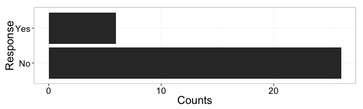

### What is so called big data?

- **Wikipedia** says : Big data usually includes data sets with sizes beyond the ability of commonly used software tools to capture, curate, manage, and process the data within a tolerable elapsed time.
- 3V, some people add another V for value, some add even more

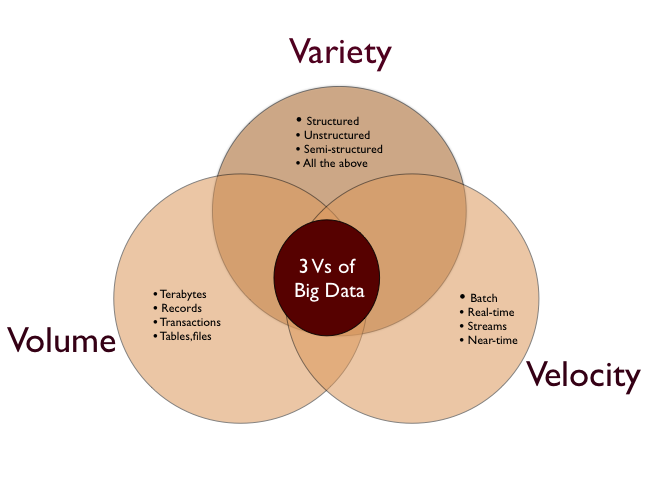

  source: http://kavyamuthanna.files.wordpress.com/2013/01/picture-11.png
- Its a concept, not actual size
- Most of you who will work as a data scientist may not even see big data

### What is data science?

Taken from your comments on homework zero

- Data science is used in the analysis of data. Data analysis is important for making companies more efficient by finding patterns in the data that company compiles.
- Data Science is a new technology that works with big data
- Data Science is a collaboration of several fields of study in an effort to form a new strategic and intelligent way of describing and presenting a very large data set.
- Data science is being able to extract useful knowledge from any data set
- It is used to organize large amounts of data created in most companies
- I understand data science to be the study of identifying relationships/patterns
- I do not know much about Data Science but I am interested

Which comments did you like best?

### Cleveland's article about data science

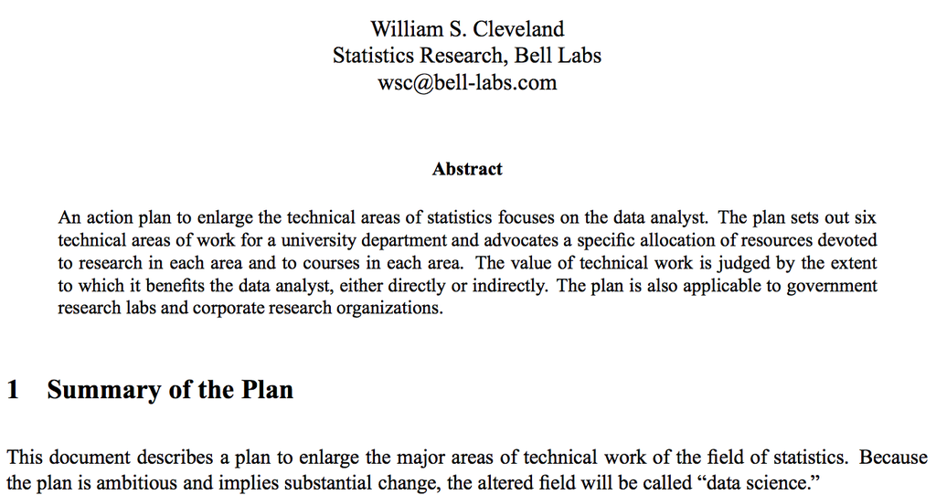

Is it a definition or presenting required skill?

### Definition: Data Science

- Arts and Science of transforming data
- Data products

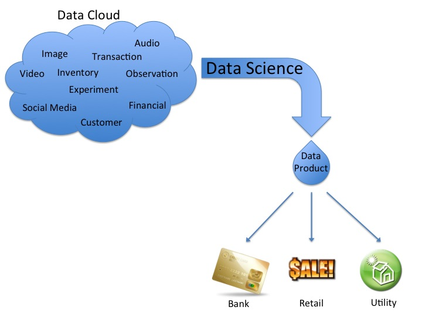

### Data Science is not computer science

- Data management
- Data technology
- Data access
- Reports

### Data Science is not statistics

- Well, Cleveland's article says some of it, I leave it a homework problem
- Does Statistics focus on data product?
- Lots of data are now generated without having any statistical planning, but they can still provide deliverable data products

## What is data product?

### Data product

- A data dependent product that has some commercial value
  - Could be another data set summarizing the original bigger data set
  - An online tool to visualize or explore important information
  - Mobile app
  - Could be a report based on data
- **Can a journal article be a data product?**

### A simplest data product example

[interactive chart not shown]

### Examples of data product

How do you think your credit score is calculated?

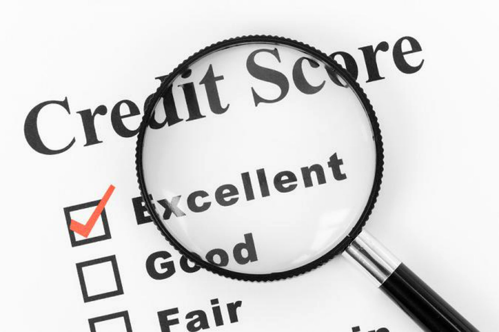

source: http://workablewealth.com/what-millennials-need-to-know-about-their-credit-score/

### What is the value of your used car?

[figure not shown]

### Data product in action

[interactive chart not shown]

### What is this course about?

- This course is not all of data science
- This is just an introduction
- We are offering other courses to the program

### UNO Data Science components

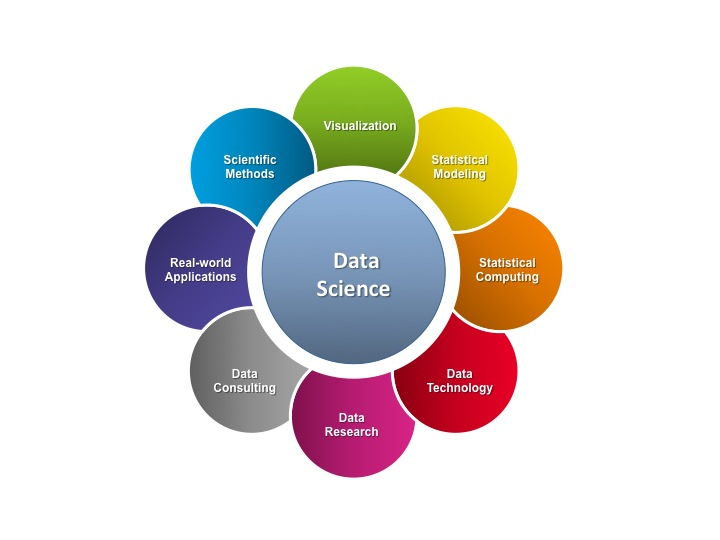

### Reading assignments

- What Wikipedia has to say about data science  
  http://en.wikipedia.org/wiki/Data_science
- A very fundamental article by Cleveland, W. S. (2001). Data science: an action plan for expanding the technical areas of the field of statistics. International Statistical Review / Revue Internationale de Statistique, 21-26  
  [http://www.stat.purdue.edu/~wsc/papers/datascience.pdf](http://www.stat.purdue.edu/%7Ewsc/papers/datascience.pdf)
- A blog by Mike Loukides about data product  
  http://radar.oreilly.com/2011/09/evolution-of-data-products.html